# Introducción a la línea de comandos (Terminal) y la sintaxis de la lenguage R

# 4) Más visualización

# 4.1) Diagrama de dispersión

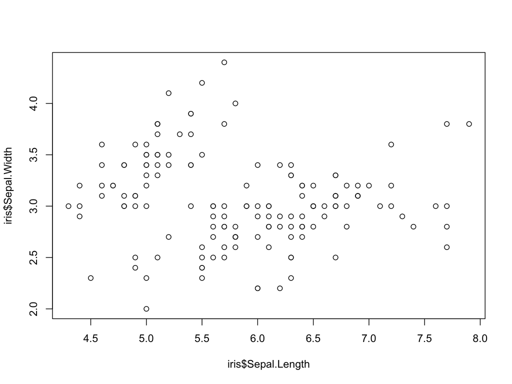

```r
plot (data = iris, iris $ Sepal.Length, iris $ Sepal.Width) ## R se quejará de este comando
```

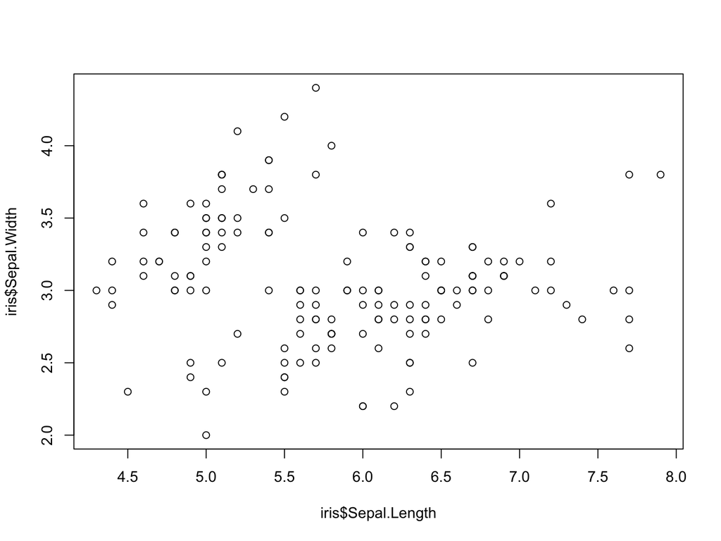

```r
plot (iris $ Sepal.Length, iris $ Sepal.Width) ## De acuerdo con el error, esto se trazó usando un Synthax diferente
```

# 4.2) Diagrama de caja

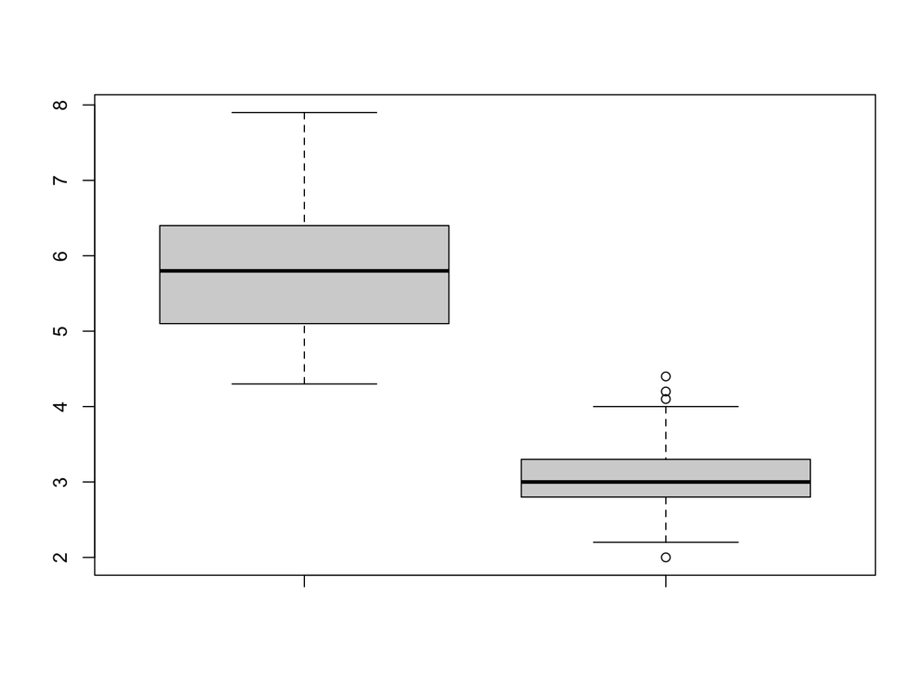

```r
boxplot (datos = iris, iris $ Sepal.Length, iris $ Sepal.Width)
```

# 5) Visualización de datos con bibliotecas especializadas

- En R, hay paquetes diseñados con el propósito de hacer gráficos atractivos. Este es el caso del ggplot2. El siguiente fragmento instala la biblioteca ggplot2, carga la biblioteca en el entorno R y luego traza los datos presentes en el marco de datos del iris.
- Puede descomentar la línea de instalación si necesita instalarla

# 5.1) Ggplot2

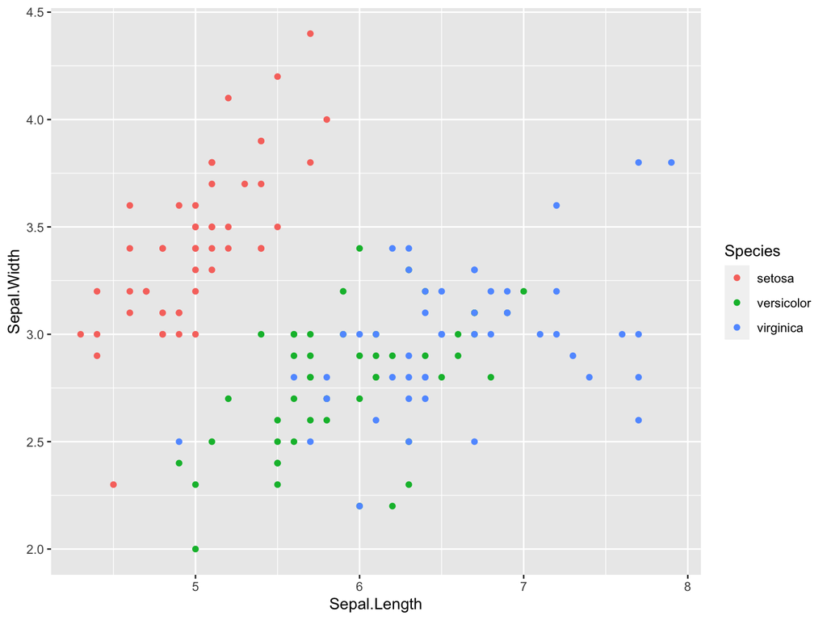

```r
# install.packages ("ggplot2")
library (ggplot2)
ggplot (data = iris, aes (x = Sepal.Length, y = Sepal.Width, color = Species)) + geom_point (tamaño = 4)
```

En nuestras actividades para visualizar datos genómicos humanos, usaremos una biblioteca llamada qqman, para visualizar la asociación biológica, a través de un diagrama conocido como diagrama de Manhattan.

# 5.2) Visualización de GWAS

La definición más simple de un GWAS es la asociación estadística o significativa entre un fenotipo (rasgo) y un genotipo. Esta asociación se puede llamar asociación biológica.

# 5.3.1) Instalación del paquete

- Necesitamos instalar y cargar el paquete qqman

```r
## install.packages ("qqman")
library (qqman)
```

```
## For example usage please run: vignette('qqman')
```

```
## Citation appreciated but not required:
```

```
## Turner, (2018). qqman: an R package for visualizing GWAS results using Q-Q and manhattan plots. Journal of Open Source Software, 3(25), 731, https://doi.org/10.21105/joss.00731.
```

- Después, cargamos el marco de datos para visualizarlo.
- Se debe determinar la ubicación exacta del archivo de texto en su sistema

```r
GWAS_TABLE <- read.table ("chr4.txt",
                         sep = " ",
                         header = T)
```

# 5.3.3) Obtener información sobre el objeto con head ()

- Utilice la función head () para inspeccionar el marco de datos recién cargado

```r
head (GWAS_TABLE, n = 10)
```

```
##    CHR         SNP     BP         P
## 1    4 chr4:128096 128096 0.0133500
## 2    4 chr4:516586 516586 0.0076260
## 3    4 chr4:523979 523979 0.0024960
## 4    4 chr4:527217 527217 0.0217400
## 5    4 chr4:566177 566177 0.0008988
## 6    4 chr4:578679 578679 0.0162100
## 7    4 chr4:578790 578790 0.0103700
## 8    4 chr4:579307 579307 0.0334600
## 9    4 chr4:580259 580259 0.0190400
## 10   4 chr4:585318 585318 0.0317600
```

# 5.3.4) Trazado de tramas de datos GWAS

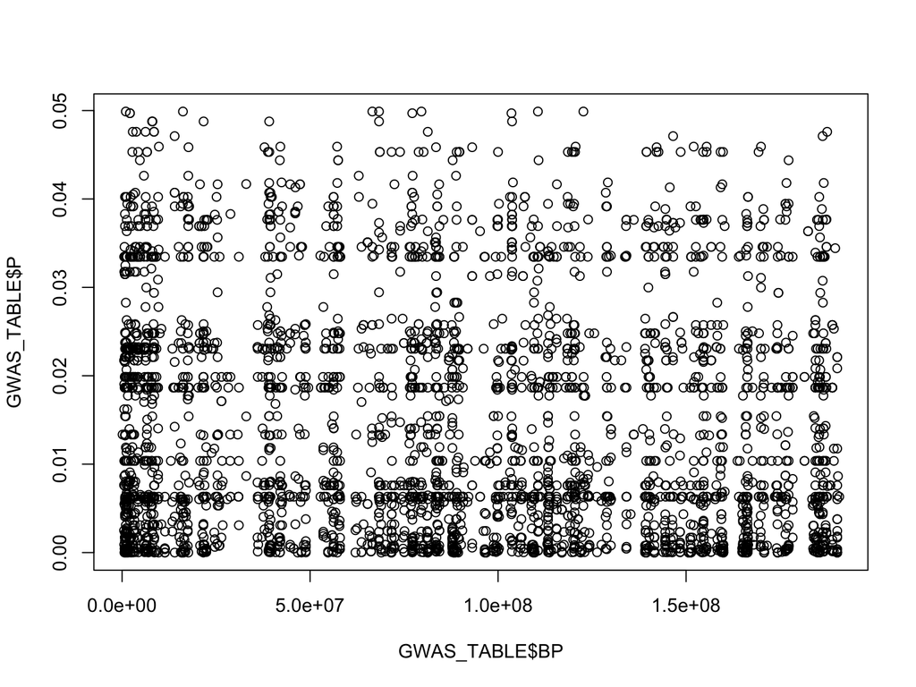

```r
plot (data = GWAS_TABLE, GWAS_TABLE $ BP, GWAS_TABLE $ P) ## R se queja
```

# 5.3.4) Trazado de tramas de datos GWAS

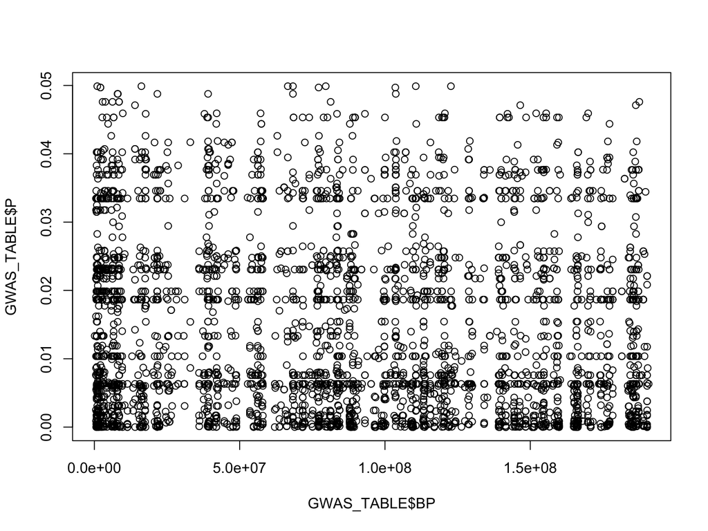

```r
plot (GWAS_TABLE $ BP, GWAS_TABLE $ P) ## R no se queja
```

# 5.4) Diagrama de caja

- Diagrama de caja

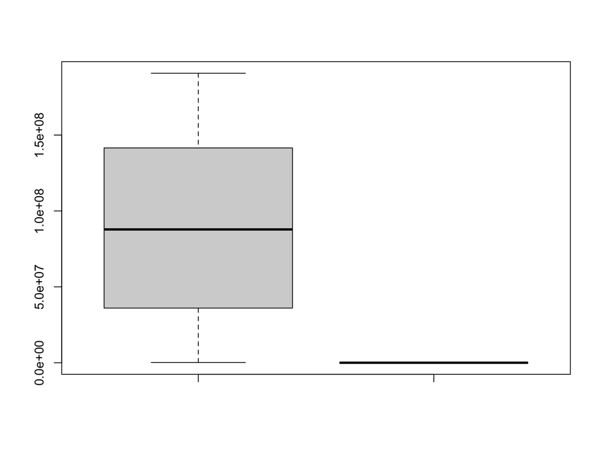

```r
boxplot (datos = GWAS_TABLE, GWAS_TABLE $ BP, GWAS_TABLE $ P)
```

# 5.5) Diagrama de caja

- Compare las coordenadas cromosómicas y los valores de los valores p en el diagrama de caja de arriba
- El fragmento siguiente permite omitir valores NA en el marco de datos

```r
GWAS_TABLE_Ommit <- na.omit(GWAS_TABLE)
```

# 5.6) Crear un vector para resaltar las coordenadas del genoma en el diagrama de Manhattan

```r
SNP_HIGHLIGHT <- c("chr4:3043512","chr4:3043513","chr4:3048207","chr4:3224216",
                   "chr4:3231772","chr4:3233844","chr4:3235081","chr4:3235084",
                   "chr4:3236881","chr4:3236883","chr4:3241845","chr4:3243804",
                   "chr4:3263138","chr4:3265130","chr4:3265710","chr4:3314646",
                   "chr4:3380088","chr4:3409359","chr4:3411110","chr4:3415336",
                   "chr4:3415378","chr4:3438643","chr4:3446091","chr4:3449886",
                   "chr4:3473066","chr4:3476809","chr4:3480439","chr4:3487151",
                   "chr4:3496058","chr4:3496110","chr4:3506933","chr4:3508752",
                   "chr4:3510957","chr4:3512690","chr4:3517746","chr4:3518190",
                   "chr4:3529671","chr4:3532327","chr4:3533066","chr4:3746133",
                   "chr4:3747842","chr4:3748134","chr4:3765305","chr4:3765336",
                   "chr4:3944253","chr4:3944752","chr4:3944888","chr4:3946166",
                   "chr4:3946175","chr4:3969218","chr4:4051294","chr4:4076788",
                   "chr4:4103104","chr4:4103105","chr4:4109198","chr4:4109210",
                   "chr4:4240627","chr4:4242705","chr4:4243668","chr4:4245210",
                   "chr4:4245510","chr4:4245513","chr4:4245591","chr4:4245926",
                   "chr4:4245929","chr4:4246109","chr4:4246433","chr4:4246453",
                   "chr4:4246457","chr4:4246497","chr4:4249414","chr4:4249415",
                   "chr4:4249484","chr4:4271623","chr4:4275306","chr4:4304749",
                   "chr4:4318931","chr4:4318970","chr4:4319564","chr4:4319728",
                   "chr4:4319750","chr4:4322078","chr4:4709657","chr4:4732282",
                   "chr4:4789635","chr4:4822960","chr4:4824890","chr4:4825092",
                   "chr4:4825180","chr4:4865316","chr4:4865321","chr4:5018702",
                   "chr4:5812778","chr4:5814082","chr4:5833660","chr4:5833899",
                   "chr4:5835541","chr4:5851205","chr4:5862752","chr4:5862938",
                   "chr4:5862943","chr4:5901873","chr4:5905499","chr4:5906287",
                   "chr4:6018891","chr4:6019046","chr4:6020190","chr4:6020367",
                   "chr4:6025638","chr4:6025656","chr4:6025766","chr4:6026058",
                   "chr4:6083488","chr4:6204935","chr4:6235553","chr4:6237142",
                   "chr4:6238466","chr4:6239906","chr4:6240929","chr4:6245022",
                   "chr4:6245618","chr4:6245732","chr4:6245915","chr4:6246075",
                   "chr4:6246373","chr4:6246959","chr4:6290594","chr4:6292020",
                   "chr4:6294095","chr4:6298375","chr4:6316092","chr4:6321396",
                   "chr4:6324647","chr4:6324785","chr4:6327669","chr4:6328354",
                   "chr4:6328507","chr4:6333130","chr4:6333559","chr4:6333669",
                   "chr4:6335966","chr4:6435341","chr4:6435486","chr4:6435926",
                   "chr4:6437191","chr4:6437197","chr4:6457121","chr4:6457131",
                   "chr4:6457132","chr4:6568390","chr4:6570032","chr4:6570768",
                   "chr4:6596360","chr4:6613252","chr4:6613462","chr4:6620991",
                   "chr4:6624771","chr4:6626154","chr4:6641969","chr4:6642090",
                   "chr4:6644466","chr4:6644467","chr4:6644468","chr4:6647889",
                   "chr4:6648300","chr4:6662665","chr4:6663319","chr4:6663715",
                   "chr4:6674554","chr4:6678553","chr4:6678599","chr4:6690535",
                   "chr4:6698664","chr4:6698667","chr4:6698706","chr4:6720572",
                   "chr4:6911679","chr4:6985889","chr4:6987394","chr4:7002344",
                   "chr4:7004495","chr4:7004506","chr4:7005196","chr4:7005199",
                   "chr4:7024077","chr4:7024398","chr4:7029430","chr4:7031064",
                   "chr4:7044357","chr4:7044380","chr4:7048842","chr4:7052115",
                   "chr4:7055253","chr4:7064243","chr4:7067765","chr4:7073187",
                   "chr4:7074027","chr4:7677967","chr4:7701947","chr4:7702795",
                   "chr4:7703505","chr4:7703807","chr4:7704795","chr4:7704818",
                   "chr4:7709703","chr4:7712150","chr4:7714490","chr4:7733843",
                   "chr4:7735162","chr4:7735164","chr4:7736103","chr4:7736112")
```

# 5.7) Trazar la parcela de Manhattan

- Finalmente, trazamos el gráfico de la trama de Manhattan

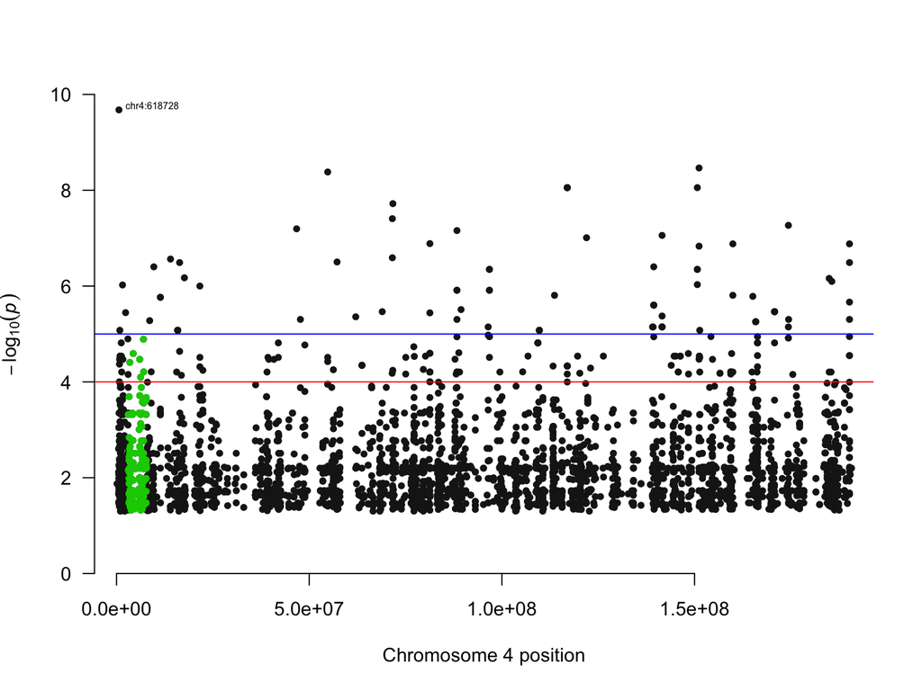

```r
manhattan(GWAS_TABLE_Ommit,
          highlight = SNP_HIGHLIGHT,
          annotateTop = T,
          annotatePval = 0.20,
          genomewideline = -log10(0.0001))
```